# Специфика медицинских данных

1. Дайте описательную статистику для переменных, включённых в датасет. Дополнительно рассчитайте, у какого количества пациентов и в каком проценте случаев у пациентов был снижен уровень гемоглобина? Используйте следующие референтные значения (Мужчины: 13.5–16 г/дл, Женщины: 12–14 г/дл).

```
## Количество пациентов с пониженным гемоглобином: 474
```

```
## Процент пациентов с пониженным гемоглобином: 46.28906 %
```

2. Рассчитайте индекс массы тела у пациентов (кг / м2). Каков был средний (M (SD)) уровень ИМТ у пациентов, включённых в исследование? Какая доля пациентов имела ожирение (ИМТ > 30)?

```
##    Min. 1st Qu.  Median    Mean 3rd Qu.    Max.
##   18.44   24.25   25.91   26.00   27.71   34.74
```

```
## Средний BMI: 26.00361
```

```
## Стандартное отклонение BMI: 2.566121
```

```
## Процент пациентов с ожирением (BMI > 30): 6.738281 %
```

3. Как выглядит ROC-кривая для предсказания летального исхода в течение 24 часов по переменной, характеризующей уровень гемоглобина? Постройте график. Чем может быть обусловлена такая форма кривой?

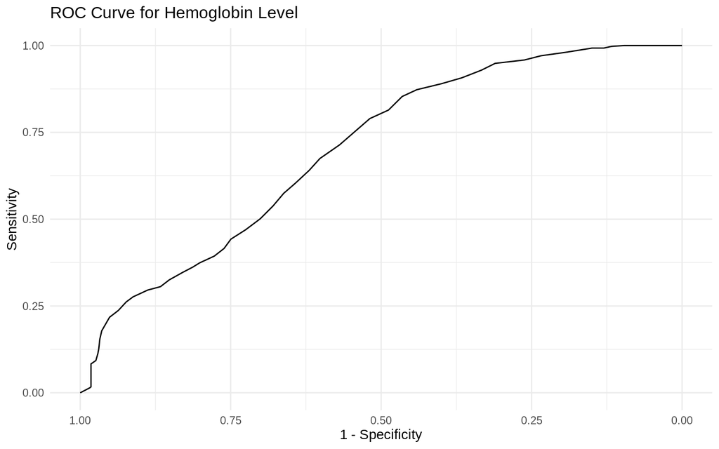

```
##   threshold specificity sensitivity
## 1       Inf 0.000000000           1
## 2     16.05 0.001626016           1
## 3     15.85 0.004878049           1
## 4     15.75 0.009756098           1
## 5     15.65 0.013008130           1
## 6     15.50 0.016260163           1
```

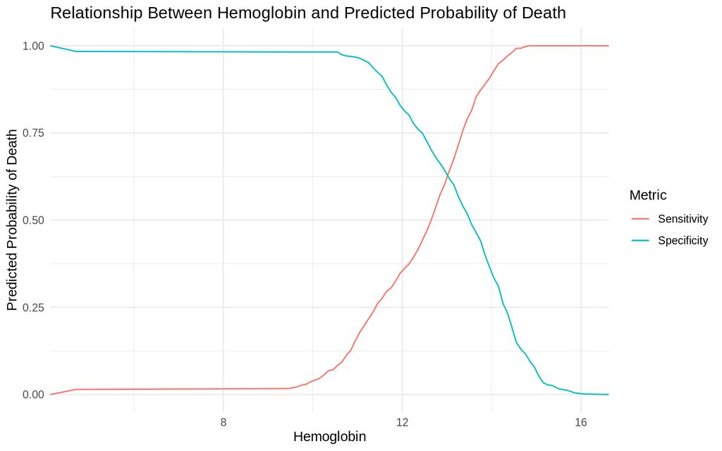

Чему равна площадь под ROC-кривой, которую вы построили в вопросе 3? Чему равен 95% двусторонний ДИ для площади под ROC-кривой, которую вы построили в вопросе 3?

```
## AUC: 0.7005983
```

```
## 95% ДИ: 0.6691296 - 0.732067
```

Исходя из полученного интевала (0.67 - 0.73) можно предположить низкую или умеренную диагностическую информативность уровня гемоглобина при предсказании смертности в течении 24 часов. 5. Проведите ROC-анализ и определите, какое пороговое значение является оптимальным для предсказания летального исхода в течение 24 часов по шкале комы Глазго. Какой чувствительностью и специфичностью обладает данный порог?

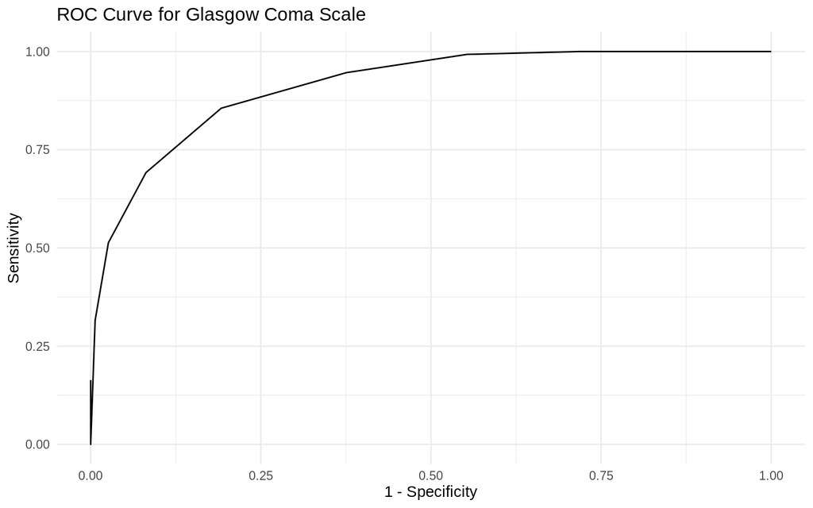

```
##   threshold specificity sensitivity
## 1       7.5   0.8081301   0.8557457
```

6. Какая из количественных переменных в датасете (включая рассчитанный вами ранее ИМТ) обладает наибольшей площадью под ROC-кривой? Как вы можете интерпретировать это знание? Какая количественная переменная имеет наименьшую площадь?

```
## # A tibble: 11 × 4
##    name              AUC AUC_LCL AUC_UCL
##    <chr>           <dbl>   <dbl>   <dbl>
##  1 Age             0.527   0.491   0.563
##  2 BMI             0.502   0.465   0.538
##  3 DBP             0.744   0.714   0.774
##  4 FOUR            0.934   0.92    0.948
##  5 GSC             0.912   0.896   0.929
##  6 Hb              0.701   0.669   0.732
##  7 Height          0.482   0.445   0.518
##  8 SBP             0.786   0.759   0.814
##  9 Weight          0.518   0.482   0.554
## 10 height_reversed 0.518   0.482   0.555
## 11 id              0.506   0.469   0.543
```

Наибольшее AUC получается при использовании колонки FOUR, которая в свою очередь шкала комы при поступлении, учитывающая глазные, двигательные, стволовые, дыхательные реакции и паттерны. Чем выше значение AUC тем лучше можно предсказать response переменную (выше чувствительность и точность). Получается что FOUR имеет наибольшую предсказательную силу.

Наименьшее AUC получается при использовании колонки Height. Однако, если использовать значения 1-Height (обратная зависимость смертности от роста), то она перестанет быть самой меньшей. И тогда видно что ближе всего к площади равной 0.5 колонка BMI, она и является наименьшей по площади.

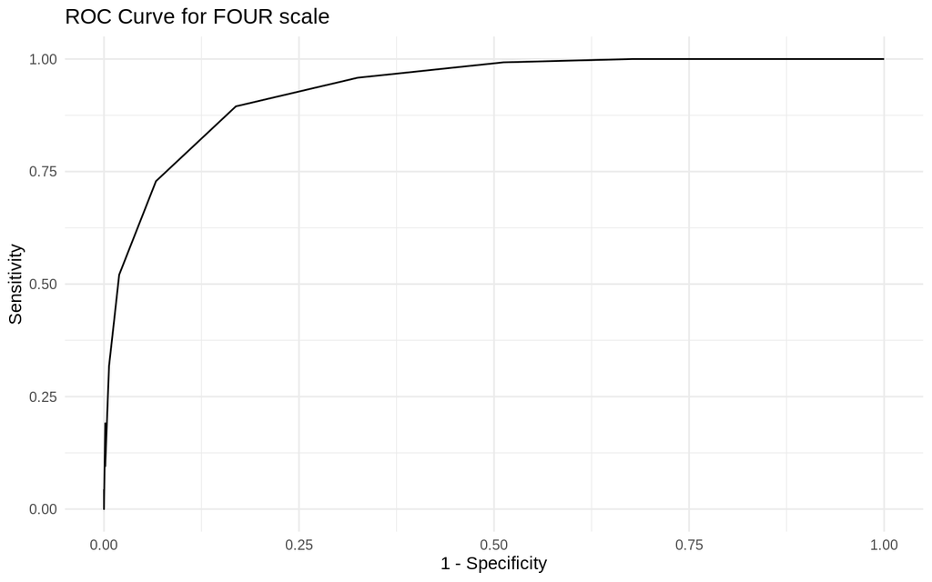